# Revenue and Insurance Product Prediction using Census Data

Group 6(Akshay, Anusha, Ashish)

April 3, 2019

## Introduction

### Problem Description

A financial institution wants to analyze the demographic information of the US population to predict:

1. Revenue earned by the company for a given ZIP code
2. The most popular product sold in a given ZIP code:
   - college fund
   - retirement fund
   - life insurance

### Data

The sample data given is a portion of the American Community Survey 2015 from census.gov. It contains several fields detailing population, gender, and business metrics grouped by selected ZIP codes throughout the United States.

## Importing Data

### Libraries Required

```r
require(Rmisc) # draw multiple plots
require(readxl) # read excel input
require(DT) # display table on HTML page
require(tidyverse) # perform data manipulation
require(kableExtra)  # display table on HTML page
require(ggplot2) # perform data visualization
require(FNN) # KNN
require(GGally) # plot correlation plots
require(car) # check variance inflation factor
require(nnet) # perform multinomial logistic regression
options(scipen = 999) # do not display numbers in scientific format
```

### Reading data

**Importing Data**

```r
# reading predictor variable data
data <- read_excel("american_fact_finder.xlsx", sheet = "census_train")

# reading response variable data
data_response <- read_excel("american_fact_finder.xlsx", sheet = "response_variable")

# reading id-geographic mapping data
data_mapping <- read_excel("american_fact_finder.xlsx", sheet = "id_geography_mapping")

# renaming predictor variable data
colnames(data) <- c("Id2",
                    "tot_population",
                    "tot_male_population",
                    "tot_female_population",
                    "perc_male_under_5yrs",
                    "perc_male_45_49yrs",
                    "perc_male_50_54yrs",
                    "perc_male_55_59yrs",
                    "perc_male_5_14yrs",
                    "perc_male_15_44yrs",
                    "perc_male_over_60yrs",
                    "perc_female_under_5yrs",
                    "perc_female_45_49yrs",
                    "perc_female_50_54yrs",
                    "perc_female_55_59yrs",
                    "perc_female_5_14yrs",
                    "perc_female_15_44yrs",
                    "perc_female_over_60yrs",
                    "male_median_age",
                    "female_median_age",
                    "no_establishments",
                    "paid_employees",
                    "payroll_quarter1",
                    "annual_payroll")

# renaming column names of response variable data
colnames(data_response) <- c("geographic_area_name",
                             "revenue",
                             "popular_product")

# renaming column names of id-geographic mapping data
colnames(data_mapping) <- c("Id2",
                             "geographic_area_name")
```

**Data Dictionary**

Predictor Variable Data

| Variable | Description |
| --- | --- |
| Id2 | Unique Zipcode ID |
| tot_population | Total Population |
| tot_male_population | Total Male Population |
| tot_female_population | Total Female Population |
| perc_male_under_5yrs | Percentage of Males Under 5 Years of Age |
| perc_male_45_49yrs | Percentage of Males Between 45-49 Years of Age |
| perc_male_50_54yrs | Percentage of Males Between 50-54 Years of Age |
| perc_male_55_59yrs | Percentage of Males Between 55-59 Years of Age |
| perc_male_5_14yrs | Percentage of Males Between 5-14 Years of Age |
| perc_male_15_44yrs | Percentage of Males Between 15-44 Years of Age |
| perc_male_over_60yrs | Percentage of Males Over 60 Years of Age |
| perc_female_under_5yrs | Percentage of Females Under 5 Years of Age |
| perc_female_45_49yrs | Percentage of Females Between 45-49 Years of Age |
| perc_female_50_54yrs | Percentage of Females Between 50-54 Years of Age |
| perc_female_55_59yrs | Percentage of Females Between 55-59 Years of Age |
| perc_female_5_14yrs | Percentage of Females Between 5-14 Years of Age |
| perc_female_15_44yrs | Percentage of Females Between 15-44 Years of Age |
| perc_female_over_60yrs | Percentage of Females Over 60 Years of Age |
| male_median_age | Median Age of Males in Years |
| female_median_age | Median Age of Females in Years |
| no_establishments | Number of Establishments |
| paid_employees | Paid employees for pay period including March 12 (number) |
| payroll_quarter1 | First-quarter payroll ($1,000) |
| annual_payroll | Annual payroll ($1,000) |

Response Variable Data

| Variable | Description |
| --- | --- |
| geographic_area_name | Geographic Area Name |
| revenue | Revenue |
| popular_product | Popular Product |

ID-Geography Mapping Data

| Variable | Description |
| --- | --- |
| Id2 | Unique Zipcode ID |
| geographic_area_name | Geographic Area Name |

**Viewing Data**

Predictor Variable Data

```r
# display first 100 rows
kable(head(data, 100)) %>%
  kable_styling(bootstrap_options = c("striped", "hover", "responsive")) %>%
  scroll_box(width = "100%", height = "500px")
```

44319

22592

11419

11173

4.2

7.3

8.6999999999999993

9.4

9.4

36.200000000000003

24.8

4.5

6.5

8.1

8.4

9.1999999999999993

34.9

28.5

45.1

45.8

582

6810

43116

196189

73067

2146

1171

975

2.8

7.9

8.4

7.9

13.1

39.1

20.8

5.2

8.1

9.3000000000000007

8.1

11.1

31.7

26.5

41.4

45.7

33

205

1724

6045

1851

30022

14858

15164

8.1

7.8

7.3

6.3

11.2

46.1

13

6.1

7.4

6.8

6.4

13.6

43.6

16.100000000000001

32.799999999999997

34.4

450

8568

147660

551236

67335

3332

1803

1529

7

6.2

8.8000000000000007

9.1999999999999993

12.9

34.1

22

2

5.6

6.1

8.6

13.7

33.6

30.3

41.4

45.8

52

491

2852

12186

72524

280

162

118

17.3

12.3

0

13

15.4

30.9

11.1

0

16.100000000000001

0

0

0

49.2

34.700000000000003

30.4

46.1

9

93

470

2592

35901

19573

9359

10214

6.9

6.3

6.2

7.8

13.9

38.799999999999997

20.100000000000001

5.8

7.4

5.9

8.3000000000000007

9.9

36.4

26.3

38.200000000000003

43.5

714

9219

66462

289032

8752

2367

1229

1138

4.4000000000000004

3.4

6

9.3000000000000007

7.9

23

46

0

8.8000000000000007

5.7

8.5

3.8

25

48.2

58.8

58.4

58

273

1705

10276

35063

3900

1945

1955

6.4

6.9

8.3000000000000007

9.1999999999999993

12.6

32.4

24.2

3.7

7.1

10.5

4.8

13.5

29

31.5

42.8

47.5

13

47

263

1146

48114

20600

10152

10448

4.3

7.8

10

9.1

13.3

34.4

21.1

4.0999999999999996

8.1

8.6

9.1999999999999993

12.8

33.299999999999997

24

43.2

44.9

505

4086

41436

188834

20037

15687

7384

8303

1.5

4

2.5

4.5999999999999996

0

71.7

15.7

1.4

3

2.8

1.6

1

74.5

15.6

30.7

24.3

829

25487

609829

2389256

54421

3270

1583

1687

5.9

7.3

8.1

6.4

18.600000000000001

34.4

19.3

7.5

5.9

7.8

4.4000000000000004

16.7

30.7

27

36.799999999999997

40.5

71

997

8410

34853

79070

10333

5282

5051

9.8000000000000007

6

6.6

6.3

18.3

40.799999999999997

12.2

8.1999999999999993

7.5

5.3

5.7

18.399999999999999

40.200000000000003

14.7

30.4

32.5

348

3862

53937

200034

49676

3441

1736

1705

6

5.6

6

8.6999999999999993

10.5

31

32

3

8.3000000000000007

7.8

7.1

8.3000000000000007

33.700000000000003

31.7

48.4

46.9

51

312

2928

12681

3583

933

424

509

3.8

8.3000000000000007

11.3

8

8.3000000000000007

22.6

37.700000000000003

3.5

11.2

10.199999999999999

10.4

8.1

21.2

35.4

52.3

53.8

25

175

1459

9473

54454

1442

742

700

5.3

8.1

9.6999999999999993

11.6

11.9

35.200000000000003

18.3

6.9

5.3

8.1

11.1

15.1

37.4

16

42.5

38.5

17

92

548

2438

8019

1012

516

496

3.1

11.4

12.2

6.2

5.6

43.4

18

4.2

9.1

9.3000000000000007

6.3

10.1

36.1

25

42.3

44.7

14

45

439

2337

36003

1716

873

843

4.8

1.9

12.7

8.1

13.6

36

22.8

1.9

9.8000000000000007

13.6

5.6

6.6

38.6

23.8

40.9

48

15

128

751

3257

13335

1606

851

755

6.3

15.9

8.5

6.2

9.1999999999999993

33.299999999999997

20.7

7.3

7.9

7.8

5.3

13.9

34.799999999999997

22.9

45.5

41.4

31

1086

10991

47243

62215

1731

894

837

7.2

9.1

8.4

5.9

15.9

38.5

15.1

4.9000000000000004

7.6

9.1

5.5

12.1

42.3

18.5

34.4

37

42

299

1776

8537

53575

16070

8358

7712

4.8

10.3

8.1

7

14.3

40.299999999999997

15.1

4.5999999999999996

9.1

7.9

6.3

18.3

33.9

19.899999999999999

39.6

41.1

319

2548

20206

94328

79934

24062

12189

11873

9.5

4.5

4.2

5.9

19.600000000000001

49.6

6.7

9.4

6.8

5.7

4

17

49.3

7.8

28

29.9

92

1123

9648

44193

37355

25493

12334

13159

6

7.5

6.5

7.2

13.8

38

21

5

5.6

9

5.8

13.3

36.799999999999997

24.6

39.200000000000003

40.200000000000003

505

8020

66808

279814

15610

3667

1794

1873

2.2000000000000002

6.4

10.8

11.3

11.6

32.6

25.1

5.6

8.5

13.1

9.8000000000000007

13

27

22.9

48.5

47.8

45

359

2840

13443

73106

13242

6977

6265

8.1

7.3

6.7

9.1999999999999993

11.3

46.4

11.1

6.8

5.0999999999999996

5.0999999999999996

7.8

12.1

51.4

11.7

33.1

30.3

479

8560

112417

450773

1129

7377

3466

3911

7.2

7.6

8.8000000000000007

6.8

15.6

35.5

18.600000000000001

3.7

6.9

7.2

6.8

9.5

38

27.9

35.799999999999997

43.7

162

2657

15369

63623

4926

36

18

18

0

0

0

0

0

0

100

0

0

0

0

0

0

100

11

59

382

1773

28269

76360

37057

39303

8.1

7.5

6.5

4.8

15.7

46.9

10.6

7.2

7.6

5.3

5.7

14.2

47.6

12.4

32.6

34.4

1266

20659

249180

1002725

75691

2817

1435

1382

3.8

9.5

2.9

5.9

17.3

36.6

24

4.2

6.2

4.5999999999999996

7.7

22.1

31.8

23.4

40.4

36.9

71

1481

31346

98008

25670

6074

3019

3055

7.5

7.6

4.8

7.3

12.5

38.700000000000003

21.6

6.8

8.1999999999999993

7.8

6.9

10.5

38.1

21.6

35.200000000000003

42.1

48

463

2676

10959

48184

17251

8354

8897

6.5

8

8

7.1

13.7

39.700000000000003

16.899999999999999

3.9

6

6.1

9.1999999999999993

12.2

41.2

21.5

36.700000000000003

39.799999999999997

369

11888

170286

666154

2535

1511

706

805

5.5

2.8

8.1

9.3000000000000007

11

36.799999999999997

26.3

2.9

3.7

11.8

9.1999999999999993

7.6

37.5

27.3

41.9

48.5

49

166

1690

9080

15746

106

47

59

0

0

6.4

19.100000000000001

0

53.2

21.3

10.199999999999999

0

6.8

0

13.6

22

47.5

39.6

53.6

9

127

1011

4049

88008

6881

3521

3360

12.6

6.1

7.2

7.1

18.600000000000001

34.299999999999997

14.1

5.3

7.7

7.5

5.7

16.8

45.7

11.4

29.6

31.2

103

1952

16335

65725

39217

1138

418

720

0

0

0

0

0

100

0

0

0

0

0

0

100

0

20.5

20.100000000000001

12

192

806

3360

97540

8061

3893

4168

2.6

7.2

5.4

5.8

16.600000000000001

35.5

27

4.8

7.2

7.1

7.1

11.1

33.700000000000003

29

42.7

45.1

160

893

5819

26660

99169

2577

1315

1262

9.1

7.7

7.5

10

13.9

29.2

22.7

11.1

5.9

8.1999999999999993

9.1

9.9

27.4

28.4

43.4

45.9

80

606

4716

23112

32955

37745

17729

20016

5

7

9.9

7.2

12.7

32.4

25.8

4.4000000000000004

6.6

8.1

6.2

11.9

32.6

30.1

44.9

45.8

918

11235

103807

432061

4360

517

266

251

0.8

11.7

9.4

6.8

9.4

30.1

32

1.2

9.1999999999999993

4.8

14.7

5.6

28.7

35.9

48.8

55.2

12

27

127

743

31408

10611

5919

4692

6.8

9

4.7

4.9000000000000004

8

54.1

12.7

10.8

7.2

6.6

4.2

12.5

38.6

20.100000000000001

33.6

35.200000000000003

591

15300

152484

622458

97503

12592

6309

6283

7.1

7.9

6.4

5.7

12.9

42.2

17.8

10.5

5.7

2.8

6.5

14.3

42.9

17.2

35.9

30.4

240

4858

47896

196024

61448

3706

1852

1854

4.7

6.2

7.7

7.1

12.7

34.4

27.3

3.6

6.4

6.6

7.1

12.6

29.9

33.799999999999997

43

47.5

42

216

798

4582

76177

6470

3321

3149

7.2

3.6

7.6

5.5

8.6

58.4

9.1999999999999993

14

4.5

6.5

4.4000000000000004

20.5

41.1

8.9

35.4

29.9

421

24624

358954

1390697

37324

5145

2578

2567

9.8000000000000007

4.4000000000000004

6.2

5.7

14

35.4

24.6

6.7

6.2

5.0999999999999996

9.6999999999999993

7.3

38.6

26.4

37.200000000000003

43.8

137

3201

40872

185889

47923

3519

1682

1837

6.4

6.8

7.5

6.1

16.2

40

17.100000000000001

6.8

9.3000000000000007

5.4

6.8

16.8

34.299999999999997

20.6

39.5

40.4

76

561

4186

17733

15663

418

197

221

8.1

9.6

11.7

12.2

2

16.2

40.1

2.2999999999999998

1.8

6.8

14.9

8.1

26.2

39.799999999999997

56.4

56.2

19

796

16185

65337

95120

37644

18723

18921

4.5999999999999996

8.4

10.3

8

17.600000000000001

29.4

21.9

3.6

10.4

8.6

7.5

14.5

31.1

24.3

44.3

45.4

512

3361

64597

265542

27012

25699

12259

13440

6.6

10

7.2

8.5

15

31.4

21.2

4.5999999999999996

9.4

8.3000000000000007

8.4

11.8

33.4

24.2

43.3

45.1

632

6456

47670

199328

24620

2992

1444

1548

9.6

7

7.8

5.6

10.8

40

19.2

4.7

9.9

10.9

13.5

11.4

34.799999999999997

14.8

38.299999999999997

42.8

25

219

2157

8701

46617

9403

4546

4857

6.6

5.0999999999999996

4.8

5.8

12.4

47.5

17.8

6.8

5.8

5.8

4.5

10.9

41.7

24.6

30.9

35.4

269

4948

52919

204581

28520

413

166

247

24.1

0

6

0

9.6

33.700000000000003

26.5

9.3000000000000007

0

4.5

14.6

19.399999999999999

33.6

18.600000000000001

39.4

36.6

3

4

14

60

7444

10811

4643

6168

4.4000000000000004

8.8000000000000007

12.4

6.8

10.3

27.6

29.7

2.7

7.8

9.6

5.6

11

29

34.200000000000003

49.1

49.4

351

5188

55156

228858

57031

733

367

366

3.5

7.9

7.9

8.4

10.6

42.2

19.3

5.5

4.0999999999999996

10.7

11.7

6.6

42.6

18.899999999999999

38.9

39.299999999999997

9

52

394

1811

37118

1173

551

622

1.5

8.6999999999999993

17.100000000000001

0

10.199999999999999

39.4

23.2

3.7

10.8

7.6

8.8000000000000007

18.3

34.1

16.7

34.9

40.200000000000003

5

16

152

611

5252

245

114

131

0

6.1

14

17.5

7

21.9

33.299999999999997

3.1

11.5

9.1999999999999993

17.600000000000001

3.1

26.7

29

55.3

53.4

19

97

1271

5283

7601

44035

22132

21903

6.5

8

7.6

6.5

9.1

46.1

16.3

6.9

7.3

7

7.6

6.8

42.8

21.6

37.9

40.299999999999997

2273

40913

538677

2340830

12928

1882

962

920

2.2999999999999998

6.3

10.199999999999999

8.9

12.7

33.1

26.5

2.6

5.8

8.9

7.2

12.9

36.700000000000003

25.9

47.6

41.4

29

151

1054

4284

18818

1281

673

608

4

9.6999999999999993

11

7.9

12.3

27

28.1

3.1

5.6

12.5

11.3

7.4

31.4

28.6

48.4

51.3

26

202

1580

7545

59936

487

255

232

0

7.1

0

5.5

8.1999999999999993

60

19.2

0

7.3

8.1999999999999993

2.6

8.1999999999999993

41.8

31.9

32.299999999999997

44.5

37

90

480

6205

98037

27994

13631

14363

5.8

6.9

7.4

6.7

12.4

44

16.899999999999999

5.7

6.2

7.6

6.9

12.9

41.7

19

36.5

37.5

926

11958

103085

427303

25245

622

279

343

0

13.6

0

4.3

12.5

31.5

38

10.199999999999999

11.4

5.2

13.7

9.9

21.9

27.7

49.4

47.6

6

6

39

132

96712

8441

4590

3851

4.5999999999999996

3.2

4.3

6.9

15.6

47.8

17.600000000000001

4.0999999999999996

5.5

6.5

4.7

18.2

38.1

22.8

34.6

39.299999999999997

218

1756

11341

47992

54160

303

154

149

0.6

3.9

10.4

5.2

15.6

49.4

14.9

3.4

7.4

11.4

6.7

9.4

43.6

18.100000000000001

39.700000000000003

44.3

9

99

713

3060

77360

4949

2445

2504

5.8

7.5

2.2000000000000002

4.5999999999999996

12.1

28.1

39.6

3.1

4.5

9.1999999999999993

5.5

11.3

30.4

36

46.7

50.3

61

398

3093

15488

54495

7997

4061

3936

9.8000000000000007

6.5

7.8

6.1

13.9

35.5

20.399999999999999

5.0999999999999996

6.8

7.3

9.1

12.7

35.200000000000003

23.9

35.4

42.5

190

3966

54022

199622

30559

4410

2251

2159

0.8

5.2

7.8

6.5

13.1

35.200000000000003

31.3

4.8

4.9000000000000004

9.5

10.1

6.9

31.4

32.4

46.3

51.1

53

228

1600

6525

35592

4831

2326

2505

5.5

4.8

9.6

8.9

10.9

39.4

20.9

5.4

6.2

6.8

7.5

13.3

36.5

24.4

42.6

40

118

1464

11288

49373

41831

1001

490

511

1.4

11.4

7.3

19.2

9.8000000000000007

39.6

11.2

1

16.600000000000001

11

8.4

7.4

39.1

16.399999999999999

43.6

46.4

7

47

526

2071

82639

779

419

360

11.7

5.5

13.8

5.5

11.5

35.799999999999997

16.2

3.1

13.1

4.7

1.7

14.7

42.8

20

40.4

32.9

33

91

611

3242

20732

9973

4522

5451

7.2

10.6

7.9

5.7

14.3

37.6

16.7

7.4

4.5

7.4

7.3

16.2

43.9

13.3

37.200000000000003

33

106

773

4925

23494

67837

890

429

461

4.7

7.7

6.5

4.4000000000000004

16.600000000000001

40.6

19.600000000000001

6.7

6.5

3.3

6.7

13.4

41

22.3

35.4

33.1

37

136

1290

5098

16435

1904

945

959

6

5.3

7

11.5

11.7

37.799999999999997

20.6

7

7

10.5

7

12.3

36.799999999999997

19.399999999999999

40.9

41.3

25

94

731

3602

17870

15098

7382

7716

5.5

6.9

6.8

7.1

11.9

42.8

19

2.7

6.8

5.4

8

10.1

42.7

24.5

35.299999999999997

40.5

414

7571

47432

199494

77454

188

111

77

0

0

0

15.3

0

57.7

27

0

0

0

22.1

0

0

77.900000000000006

25.8

60.6

6

10

41

194

54947

2539

1269

1270

2

9.6

12.1

9.1999999999999993

7.2

31.6

28.1

4.5999999999999996

9.8000000000000007

10.199999999999999

7.4

7

30

30.9

49.9

49.6

32

110

706

3462

61475

363

160

203

2.5

18.8

8.1

2.5

8.8000000000000007

41.3

18.100000000000001

1

14.3

11.8

0

17.2

37.9

17.7

43.4

35.9

5

15

221

2292

94572

9724

4335

5389

9.1999999999999993

5

6.1

10.6

10.4

39.4

19.2

4

5

7.6

6.2

12.8

41.9

22.6

35.700000000000003

37.5

79

996

24776

77658

64643

1391

675

716

12

9.1999999999999993

4.3

6.7

14.2

30.8

22.8

5.3

7.4

4.9000000000000004

4.7

19.100000000000001

36

22.5

38.9

39.4

14

69

445

2152

70466

8560

4557

4003

6.9

4.2

6

7.2

15.2

49.4

11.1

5.2

7.4

5.8

7.1

11.5

42.5

20.5

31.8

38.799999999999997

66

325

1844

8450

92887

20292

10080

10212

5.8

7

9.5

9.3000000000000007

14.9

34.799999999999997

18.7

6.1

8.9

9.6999999999999993

9.4

11.8

34.799999999999997

19.3

40.5

43.3

625

6794

95375

376988

45389

564

280

284

5.7

3.2

18.2

5.4

15.7

30.4

21.4

4.5999999999999996

6

5.3

10.199999999999999

12

34.9

27.1

39

42.6

10

28

98

375

58538

2669

1385

1284

13.9

5.3

5.8

4.0999999999999996

21

41

8.8000000000000007

10.4

7

6.8

3.7

20.100000000000001

41.1

11

26

29.2

17

932

6505

27357

18829

888

452

436

5.8

11.9

8.8000000000000007

6.4

14.2

35.6

17.3

6.9

7.8

10.8

4.5999999999999996

13.3

30

26.6

42

44.8

12

61

276

1252

60443

21184

9728

11456

5.5

7.1

8.1

8.1

13.4

36.9

20.9

3.4

5

6.2

9.9

16.100000000000001

34.9

24.5

40

41.6

346

6291

45487

182411

21778

1077

532

545

2.6

11.8

5.0999999999999996

11.3

1.7

53

14.5

0

8.8000000000000007

6.8

11.6

22.6

35.200000000000003

15

39.799999999999997

40.200000000000003

18

109

867

4789

5251

1399

638

761

1.3

6.4

11.8

6.6

9.1

21.8

43.1

5.0999999999999996

9.3000000000000007

10.1

12.2

7.9

19.399999999999999

35.9

54.9

53.6

73

479

3763

16779

32216

37190

18268

18922

9.1

7.8

5.5

5.4

9.6

46.6

16.100000000000001

4.7

6.2

7.6

4.5999999999999996

12.4

40.799999999999997

23.7

34.6

37

1797

32050

413167

1535742

80465

15986

7934

8052

4.5999999999999996

7.8

9

8.9

11.9

34.4

23.4

5.8

8.6999999999999993

9

9.5

12.3

34.299999999999997

20.5

44.5

43.5

336

1606

12446

60620

67332

168

89

79

0

11.2

22.5

5.6

9

30.3

21.3

0

17.7

15.2

13.9

1.3

35.4

16.5

49.9

49.3

4

73

807

2977

82215

171

107

64

0

2.8

13.1

14

4.7

36.4

29

0

4.7

0

25

4.7

10.9

54.7

50.7

63.3

7

27

138

668

27863

11877

5898

5979

10.199999999999999

7.5

5.5

8

14.3

39.4

15.1

5.5

6.4

7

3.6

15.8

40.200000000000003

21.6

36.4

36.700000000000003

100

672

3985

18454

67732

437

226

211

2.2000000000000002

2.2000000000000002

11.1

12.4

12.4

25.2

34.5

7.1

2.8

14.7

9

8.5

28.4

29.4

53

50.7

16

104

895

4228

91405

53347

26612

26735

7.3

7.3

6.6

6

14.6

47.4

10.8

7.6

7.3

7.1

5.6

13.2

44.4

14.8

31.6

34.9

957

12807

126812

549159

25121

678

316

362

0

28.5

3.8

0

0

38.6

29.1

0

0

6.9

19.100000000000001

16.600000000000001

45

12.4

47.3

43.5

8

53

505

2014

19009

955

491

464

0.6

0.8

9

13.6

16.100000000000001

44.6

15.3

5.8

5.4

12.9

6.9

10.6

38.799999999999997

19.600000000000001

28.1

39.299999999999997

27

778

5335

22277

93110

17382

8997

8385

5.4

8.1

6.6

6.8

9.3000000000000007

41.4

22.5

3.6

8.5

6.2

8.8000000000000007

10.3

33.5

29.1

38.6

47.1

326

3721

69125

256148

40870

396

206

190

0

0

4.9000000000000004

12.6

5.8

48.5

28.2

11.6

7.4

5.8

12.6

13.7

31.1

17.899999999999999

43.9

38.200000000000003

4

52

418

1882

27939

2592

1209

1383

11.8

5.0999999999999996

6.6

5.5

17.8

30.4

22.7

6.5

2.5

6.9

5.0999999999999996

22.4

39.9

16.600000000000001

36.700000000000003

31.5

44

354

1646

7561

63033

42635

18843

23792

7

5.3

7.6

8.1

16

37.6

18.399999999999999

5.4

5.3

7.3

6.5

11

39.4

25.2

34.9

40.6

909

7856

42228

179903

25241

1612

910

702

6.7

8.4

4.3

5.6

15.7

41.3

18

8.1

7.3

7.1

5.4

16.5

27.2

28.3

35.799999999999997

43.8

20

65

345

1819

68532

812

484

328

9.6999999999999993

12

1.4

8.3000000000000007

15.5

42.4

10.7

2.4

25

3.7

5.8

28.4

18.899999999999999

15.9

17.899999999999999

45

10

27

184

1103

Response Variable Data

```r
# display first 100 rows
kable(head(data_response, 100)) %>%
  kable_styling(bootstrap_options = c("striped", "hover", "responsive")) %>%
  scroll_box(width = "100%", height = "500px")
```

| geographic_area_name | revenue | popular_product |
| --- | --- | --- |
| ZIP 44319 (Akron, OH) | 110168 | retirement |
| ZIP 73067 (Ninnekah, OK) | 32785 | retirement |
| ZIP 01851 (Lowell, MA) | 124838 | life |
| ZIP 67335 (Cherryvale, KS) | 48629 | college |
| ZIP 72524 (Cord, AR) | 23694 | college |
| ZIP 35901 (Gadsden, AL) | 131639 | college |
| ZIP 08752 (Seaside Park, NJ) | 37291 | college |
| ZIP 35063 (Empire, AL) | 34062 | college |
| ZIP 48114 (Brighton, MI) | 96213 | retirement |
| ZIP 20037 (Washington, DC) | 367039 | life |
| ZIP 54421 (Colby, WI) | 43943 | retirement |
| ZIP 79070 (Perryton, TX) | 74486 | college |
| ZIP 49676 (Rapid City, MI) | 38341 | college |
| ZIP 03583 (Jefferson, NH) | 26785 | retirement |
| ZIP 54454 (Milladore, WI) | 32692 | retirement |
| ZIP 08019 (Chatsworth, NJ) | 33492 | retirement |
| ZIP 36003 (Autaugaville, AL) | 33899 | life |
| ZIP 13335 (Edmeston, NY) | 37718 | retirement |
| ZIP 62215 (Albers, IL) | 31449 | retirement |
| ZIP 53575 (Oregon, WI) | 72434 | retirement |
| ZIP 79934 (El Paso, TX) | 35526 | life |
| ZIP 37355 (Manchester, TN) | 118132 | retirement |
| ZIP 15610 (Acme, PA) | 42750 | retirement |
| ZIP 73106 (Oklahoma City, OK) | 121778 | life |
| ZIP 01129 (Springfield, MA) | 51292 | college |
| ZIP 04926 (China Village, ME) | 31080 | college |
| ZIP 28269 (Charlotte, NC) | 245501 | life |
| ZIP 75691 (Tatum, TX) | 51806 | retirement |
| ZIP 25670 (Delbarton, WV) | 46552 | college |
| ZIP 48184 (Wayne, MI) | 123227 | retirement |

[output cut: 70 more lines]

ID-Geography Mapping Data

```r
# display first 100 rows
kable(head(data_mapping, 100)) %>%
  kable_styling(bootstrap_options = c("striped", "hover", "responsive")) %>%
  scroll_box(width = "100%", height = "500px")
```

| Id2 | geographic_area_name |
| --- | --- |
| 1001 | ZIP 01001 (Agawam, MA) |
| 1002 | ZIP 01002 (Amherst, MA) |
| 1003 | ZIP 01003 (Amherst, MA) |
| 1005 | ZIP 01005 (Barre, MA) |
| 1007 | ZIP 01007 (Belchertown, MA) |
| 1008 | ZIP 01008 (Blandford, MA) |
| 1009 | ZIP 01009 (Bondsville, MA) |
| 1010 | ZIP 01010 (Brimfield, MA) |
| 1011 | ZIP 01011 (Chester, MA) |
| 1012 | ZIP 01012 (Chesterfield, MA) |
| 1013 | ZIP 01013 (Chicopee, MA) |
| 1020 | ZIP 01020 (Chicopee, MA) |
| 1022 | ZIP 01022 (Chicopee, MA) |
| 1026 | ZIP 01026 (Cummington, MA) |
| 1027 | ZIP 01027 (Easthampton, MA) |
| 1028 | ZIP 01028 (East Longmeadow, MA) |
| 1029 | ZIP 01029 (East Otis, MA) |
| 1030 | ZIP 01030 (Feeding Hills, MA) |
| 1031 | ZIP 01031 (Gilbertville, MA) |
| 1032 | ZIP 01032 (Goshen, MA) |
| 1033 | ZIP 01033 (Granby, MA) |
| 1034 | ZIP 01034 (Granville, MA) |
| 1035 | ZIP 01035 (Hadley, MA) |
| 1036 | ZIP 01036 (Hampden, MA) |
| 1037 | ZIP 01037 (Hardwick, MA) |
| 1038 | ZIP 01038 (Hatfield, MA) |
| 1039 | ZIP 01039 (Haydenville, MA) |
| 1040 | ZIP 01040 (Holyoke, MA) |
| 1050 | ZIP 01050 (Huntington, MA) |
| 1053 | ZIP 01053 (Leeds, MA) |

[output cut: 70 more lines]

## Data Cleaning and Exploration

### Data Cleaning

**Missing Value Table**

```r
# all column indices except ID column
index <- 2:ncol(data)

# convert above columns to numeric
data[index] <- lapply(data[index], as.numeric)

# calculate missing values
na_table <-
  map_dbl(data, function(x) sum(is.na(x))) %>%
  sort(decreasing = TRUE) %>%
  data.frame()

# rename column
colnames(na_table) <- c("total_missing")

# display missing value table
datatable(na_table)
```

|  | total_missing |
| --- | --- |
| female_median_age | 99 |
| male_median_age | 91 |
| perc_female_under_5yrs | 51 |
| perc_female_45_49yrs | 51 |
| perc_female_50_54yrs | 51 |
| perc_female_55_59yrs | 51 |
| perc_female_5_14yrs | 51 |
| perc_female_15_44yrs | 51 |
| perc_female_over_60yrs | 51 |
| perc_male_under_5yrs | 47 |

[output cut: 14 more lines]

**Removing rows with 8 or more missing columns**

```r
 # index for row having 8 or more missing columns
index <- apply(data, 1, function(x) sum(is.na(x)) >= 8)

# removing above rows
data <- data[!index,]

# calculate missing values
na_table <-
  map_dbl(data, function(x) sum(is.na(x))) %>%
  sort(decreasing = TRUE) %>%
  data.frame()

# rename column
colnames(na_table) <- c("total_missing")

# display missing value table
datatable(na_table)
```

|  | total_missing |
| --- | --- |
| female_median_age | 43 |
| male_median_age | 36 |
| Id2 | 0 |
| tot_population | 0 |
| tot_male_population | 0 |
| tot_female_population | 0 |
| perc_male_under_5yrs | 0 |
| perc_male_45_49yrs | 0 |
| perc_male_50_54yrs | 0 |
| perc_male_55_59yrs | 0 |

[output cut: 14 more lines]

**KNN-Imputation of median ages of males and females**

```r
###### 1. male_median_age ######

# data with output variable and variables on which knn needs to be trained
tr <- na.omit(select(data, tot_population, tot_male_population,
                      perc_male_under_5yrs:perc_male_over_60yrs, male_median_age))
```

```r
# data with variables on which knn needs to be trained
tr1 <- select(tr, tot_population, tot_male_population,
              perc_male_under_5yrs:perc_male_over_60yrs)

# missing data: data on which knn would provide predictions
te1 <-
  data %>%
  filter(is.na(male_median_age)) %>%
    select(tot_population, tot_male_population,
          perc_male_under_5yrs:perc_male_over_60yrs)


# output variable
output_tr <- select(tr, male_median_age)$male_median_age

# training data for knn without output variable
train <- as.data.frame(tr1)

# test data to be imputed using knn
test <- as.data.frame(te1)

# output variable
output_var_train <- as.numeric(output_tr)

# perform k-nearest neighbour with k=20
knn_prediction_male <- knn.reg(train=train, test=test, y=output_var_train, k = 20)

# impute missing values with above algorithm
data[is.na(data$male_median_age),]$male_median_age <- knn_prediction_male$pred

###### 2. female_median_age ######

# data with output variable and variables on which knn needs to be trained
tr <- na.omit(select(data, tot_population, tot_female_population,
                      perc_female_under_5yrs:perc_female_over_60yrs, female_median_age))

# data with variables on which knn needs to be trained
tr1 <- select(tr, tot_population, tot_female_population,
              perc_female_under_5yrs:perc_female_over_60yrs)

# missing data: data on which knn would provide predictions
te1 <-
  data %>%
  filter(is.na(female_median_age)) %>%
    select(tot_population, tot_female_population,
          perc_female_under_5yrs:perc_female_over_60yrs)


# output variable
output_tr <- select(tr, female_median_age)$female_median_age

# training data for knn without output variable
train <- as.data.frame(tr1)

# test data to be imputed using knn
test <- as.data.frame(te1)

# output variable
output_var_train <- as.numeric(output_tr)

# perform k-nearest neighbour with k=20
knn_prediction_female <- knn.reg(train=train, test=test, y=output_var_train, k = 20)

# impute missing values with above algorithm
data[is.na(data$female_median_age),]$female_median_age <- knn_prediction_female$pred

# calculate missing values
na_table <-
  map_dbl(data, function(x) sum(is.na(x))) %>%
  sort(decreasing = TRUE) %>%
  data.frame()

# rename column
colnames(na_table) <- c("total_missing")

# display missing value table
datatable(na_table)
```

|  | total_missing |
| --- | --- |
| Id2 | 0 |
| tot_population | 0 |
| tot_male_population | 0 |
| tot_female_population | 0 |
| perc_male_under_5yrs | 0 |
| perc_male_45_49yrs | 0 |
| perc_male_50_54yrs | 0 |
| perc_male_55_59yrs | 0 |
| perc_male_5_14yrs | 0 |
| perc_male_15_44yrs | 0 |

[output cut: 14 more lines]

**Summary Table**

```r
# summary statistics for numerical variables
summary <- data.frame()
for(i in 2:ncol(data))
{
  name = colnames(data)[i]
  min = min(data[,i], na.rm=TRUE) %>% round(3)
  mean = mean(data[,i,drop=TRUE], na.rm=TRUE) %>% round(3)
  median = median(data[,i,drop=TRUE], na.rm=TRUE) %>% round(3)
  max = max(data[,i], na.rm=TRUE) %>% round(3) %>% round(3)
  count = sum(!is.na(data[,i]))
  df = data.frame(name, min, mean=mean, median=median, max, count)
  summary <- rbind(summary, df)
}

# display summary table
datatable(summary)
```

|  | name | min | mean | median | max | count |
| --- | --- | --- | --- | --- | --- | --- |
| 1 | tot_population | 11 | 10883.253 | 3709 | 112709 | 6785 |
| 2 | tot_male_population | 6 | 5356.299 | 1866 | 60595 | 6785 |
| 3 | tot_female_population | 4 | 5526.955 | 1842 | 52550 | 6785 |
| 4 | perc_male_under_5yrs | 0 | 5.827 | 5.7 | 47.4 | 6785 |
| 5 | perc_male_45_49yrs | 0 | 6.773 | 6.6 | 91.7 | 6785 |
| 6 | perc_male_50_54yrs | 0 | 7.566 | 7.3 | 100 | 6785 |
| 7 | perc_male_55_59yrs | 0 | 7.485 | 7 | 100 | 6785 |
| 8 | perc_male_5_14yrs | 0 | 12.68 | 12.9 | 71.4 | 6785 |
| 9 | perc_male_15_44yrs | 0 | 36.919 | 36.7 | 100 | 6785 |
| 10 | perc_male_over_60yrs | 0 | 22.75 | 21 | 100 | 6785 |

[output cut: 13 more lines]

**Minimum population greater than equal to 100**

```r
# filtering on population
data <-
  data %>%
    filter(tot_population >=100)

# summary statistics for numerical variables
summary <- data.frame()
for(i in 2:ncol(data))
{
  name = colnames(data)[i]
  min = min(data[,i], na.rm=TRUE) %>% round(3)
  mean = mean(data[,i,drop=TRUE], na.rm=TRUE) %>% round(3)
  median = median(data[,i,drop=TRUE], na.rm=TRUE) %>% round(3)
  max = max(data[,i], na.rm=TRUE) %>% round(3) %>% round(3)
  count = sum(!is.na(data[,i]))
  df = data.frame(name, min, mean=mean, median=median, max, count)
  summary <- rbind(summary, df)
}

# display summary table
datatable(summary)
```

|  | name | min | mean | median | max | count |
| --- | --- | --- | --- | --- | --- | --- |
| 1 | tot_population | 100 | 11010.794 | 3860 | 112709 | 6706 |
| 2 | tot_male_population | 9 | 5419.037 | 1921.5 | 60595 | 6706 |
| 3 | tot_female_population | 10 | 5591.757 | 1903.5 | 52550 | 6706 |
| 4 | perc_male_under_5yrs | 0 | 5.856 | 5.7 | 47.4 | 6706 |
| 5 | perc_male_45_49yrs | 0 | 6.795 | 6.7 | 76.5 | 6706 |
| 6 | perc_male_50_54yrs | 0 | 7.564 | 7.3 | 100 | 6706 |
| 7 | perc_male_55_59yrs | 0 | 7.421 | 7 | 100 | 6706 |
| 8 | perc_male_5_14yrs | 0 | 12.75 | 12.9 | 57.1 | 6706 |
| 9 | perc_male_15_44yrs | 0 | 37.074 | 36.8 | 100 | 6706 |
| 10 | perc_male_over_60yrs | 0 | 22.539 | 21 | 100 | 6706 |

[output cut: 13 more lines]

### Data Exploration

**Joining Response and Predictor Variables**

```r
# joining response and predictor variables
data <-
  data %>%
  left_join(data_mapping, by = "Id2") %>%
  left_join(data_response, by = "geographic_area_name")

# converting popular product to factor
data$popular_product <- as.factor(data$popular_product)
```

**Univariate Analysis-I**

Following variables are heavily right-skewed:

- tot_population
- tot_male_population
- tot_female_population
- no_establishments
- paid_employees

- payroll_quarter1
- annual_payroll
- revenue

Following variables are normally distributed:

- male_median_age
- female_median_age

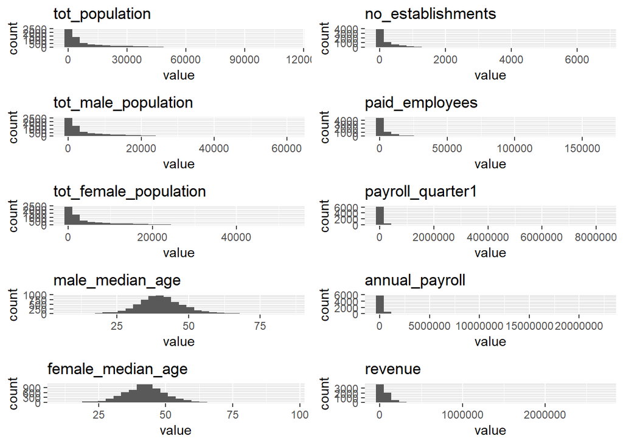

```r
edaPlot <- function(value, name)
{
  hist <- ggplot(data, aes(x=value)) +
    geom_histogram() +
    ggtitle(name)

  hist
}

p1 <- edaPlot(data$tot_population,"tot_population")
p2 <- edaPlot(data$tot_male_population,"tot_male_population")
p3 <- edaPlot(data$tot_female_population,"tot_female_population")
p4 <- edaPlot(data$male_median_age,"male_median_age")
p5 <- edaPlot(data$female_median_age,"female_median_age")
p6 <- edaPlot(data$no_establishments,"no_establishments")
p7 <- edaPlot(data$paid_employees,"paid_employees")
p8 <- edaPlot(data$payroll_quarter1,"payroll_quarter1")
p9 <- edaPlot(data$annual_payroll,"annual_payroll")
p10 <- edaPlot(data$revenue,"revenue")

Rmisc::multiplot(p1, p2, p3, p4, p5, p6, p7, p8, p9, p10, cols = 2)
```

**Univariate Analysis-II**

Most of the zipcodes have males:

1. Between 15-44 years of age
2. Over 60 years of age
3. Between 5-14 years of age

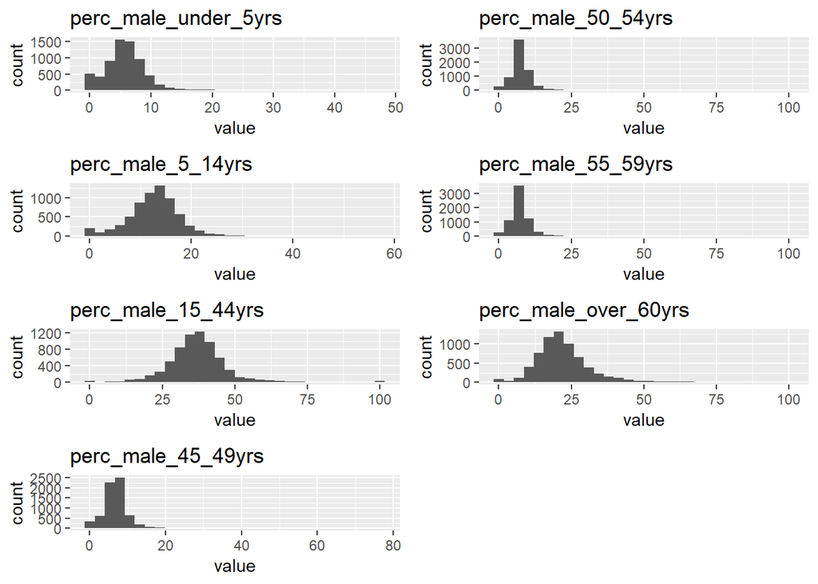

```r
p1 <- edaPlot(data$perc_male_under_5yrs,"perc_male_under_5yrs")
p2 <- edaPlot(data$perc_male_5_14yrs,"perc_male_5_14yrs")
p3 <- edaPlot(data$perc_male_15_44yrs,"perc_male_15_44yrs")
p4 <- edaPlot(data$perc_male_45_49yrs,"perc_male_45_49yrs")
p5 <- edaPlot(data$perc_male_50_54yrs,"perc_male_50_54yrs")
p6 <- edaPlot(data$perc_male_55_59yrs,"perc_male_55_59yrs")
p7 <- edaPlot(data$perc_male_over_60yrs,"perc_male_over_60yrs")

Rmisc::multiplot(p1, p2, p3, p4, p5, p6, p7, cols = 2)
```

**Univariate Analysis-III**

Most of the zipcodes have females:

1. Between 15-44 years of age
2. Over 60 years of age
3. Between 5-14 years of age

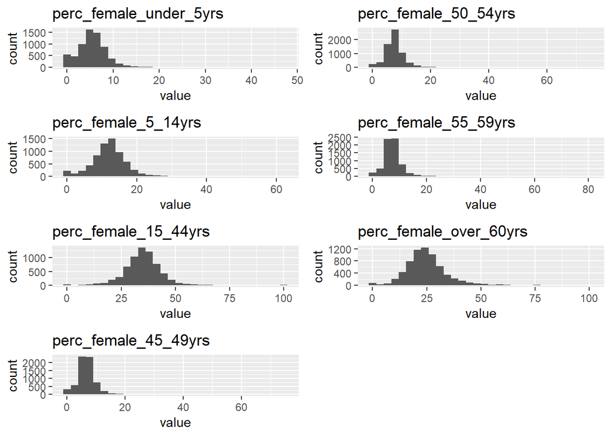

```r
p1 <- edaPlot(data$perc_female_under_5yrs,"perc_female_under_5yrs")
p2 <- edaPlot(data$perc_female_5_14yrs,"perc_female_5_14yrs")
p3 <- edaPlot(data$perc_female_15_44yrs,"perc_female_15_44yrs")
p4 <- edaPlot(data$perc_female_45_49yrs,"perc_female_45_49yrs")
p5 <- edaPlot(data$perc_female_50_54yrs,"perc_female_50_54yrs")
p6 <- edaPlot(data$perc_female_55_59yrs,"perc_female_55_59yrs")
p7 <- edaPlot(data$perc_female_over_60yrs,"perc_female_over_60yrs")

Rmisc::multiplot(p1, p2, p3, p4, p5, p6, p7, cols = 2)
```

**Univariate Analysis-IV**

Popular Products are equally distributed among college, life and retirement.

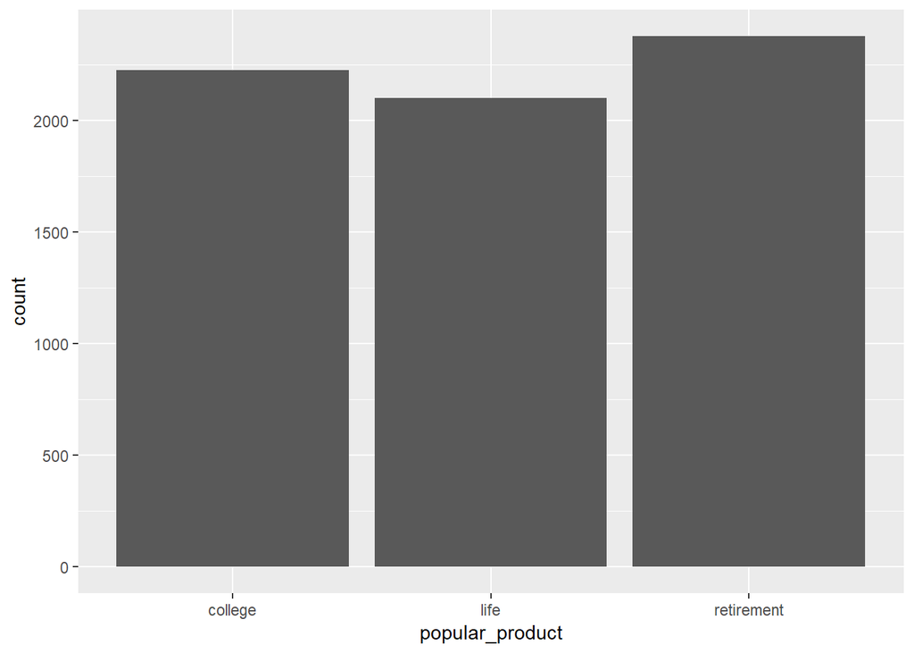

```r
ggplot(data, aes(x=popular_product)) +
  geom_bar()
```

**Revenue Bivariate Analysis-I**

*Note: See the last row only*

Revenue has high positive correlation with:

- annual_payroll
- payroll_quarter1
- paid_employees
- no_establishments

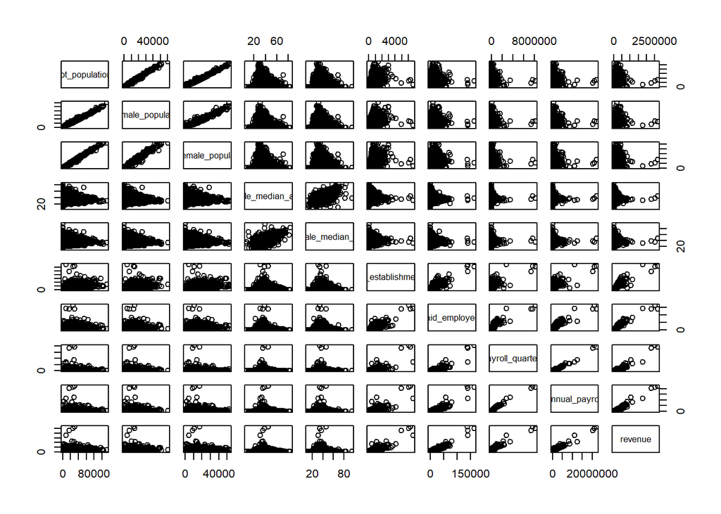

```r
df1 <- select(data, tot_population:tot_female_population
              , male_median_age:annual_payroll, revenue)

pairs(df1)
```

*Note: See the last column only*

The above inference is verified by the correlation plot

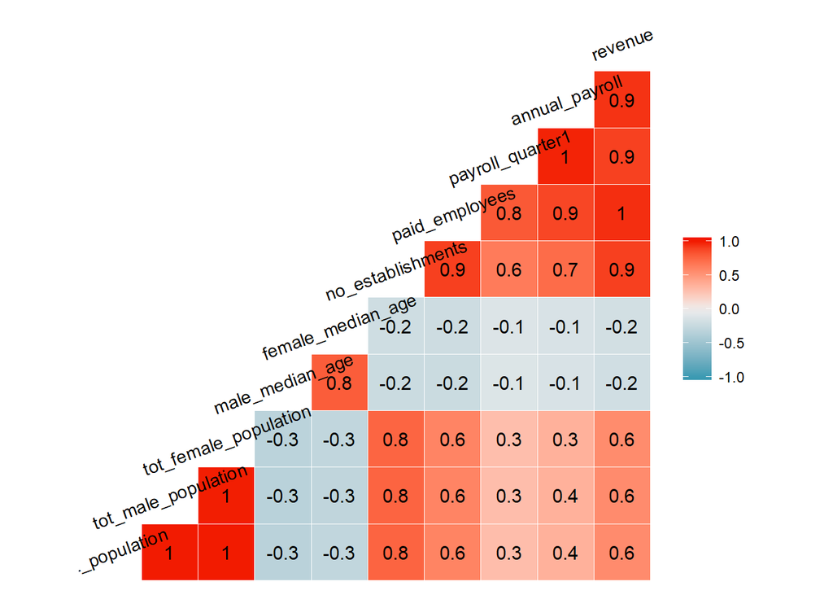

```r
ggcorr(df1, label = TRUE, angle = 20)
```

**Revenue Bivariate Analysis-II**

*Note: See the last row only*

There does not seem any significant correlations.

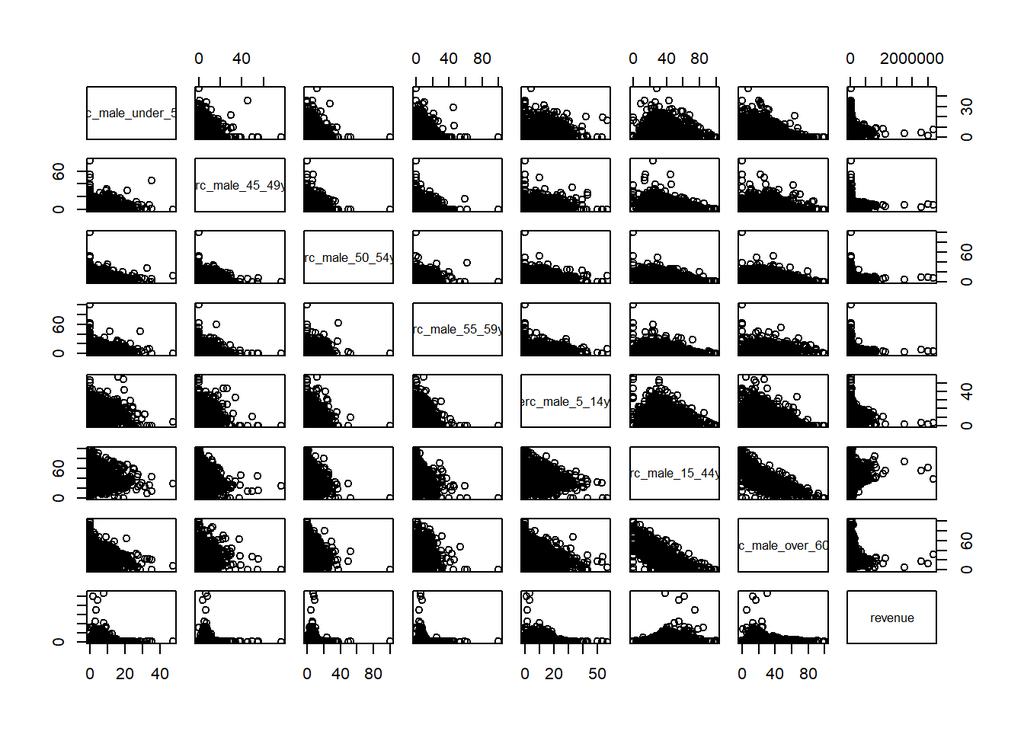

```r
df2 <- select(data, perc_male_under_5yrs:perc_male_over_60yrs, revenue)

pairs(df2)
```

*Note: See the last column only*

Observations:

- Revenue is negatively correlated with perc_male_over_60yrs. This does make sense as older the population lower the revenue generated.
- Revenue is positively correlated with perc_male_15_44yrs. This does make sense as younger the population higher the revenue generated.

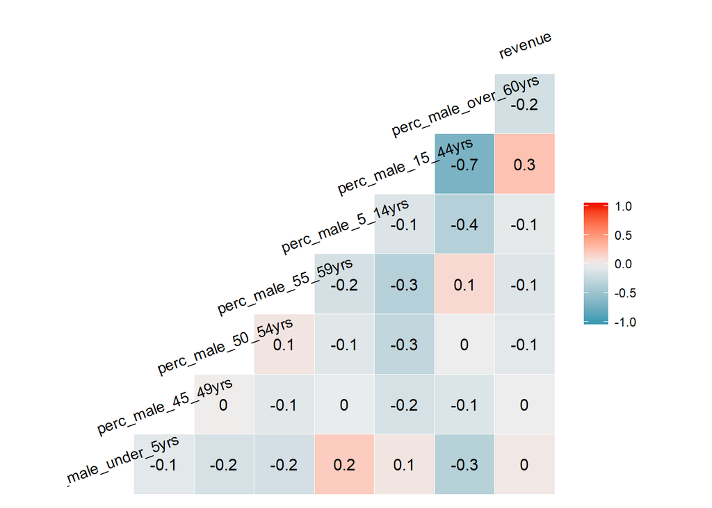

```r
ggcorr(df2, label = TRUE, angle = 20)
```

**Revenue Bivariate Analysis-III**

*Note: See the last row only*

There does not seem any significant correlations.

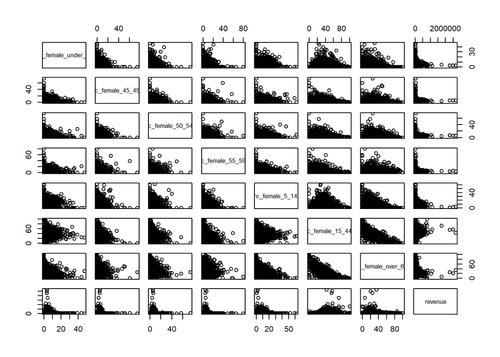

```r
df3 <- select(data, perc_female_under_5yrs:perc_female_over_60yrs, revenue)

pairs(df3)
```

Observations:

- Revenue is negatively correlated with perc_female_over_60yrs. This does make sense as older the population lower the revenue generated.
- Revenue is positively correlated with perc_female_15_44yrs. This does make sense as younger the population higher the revenue generated.

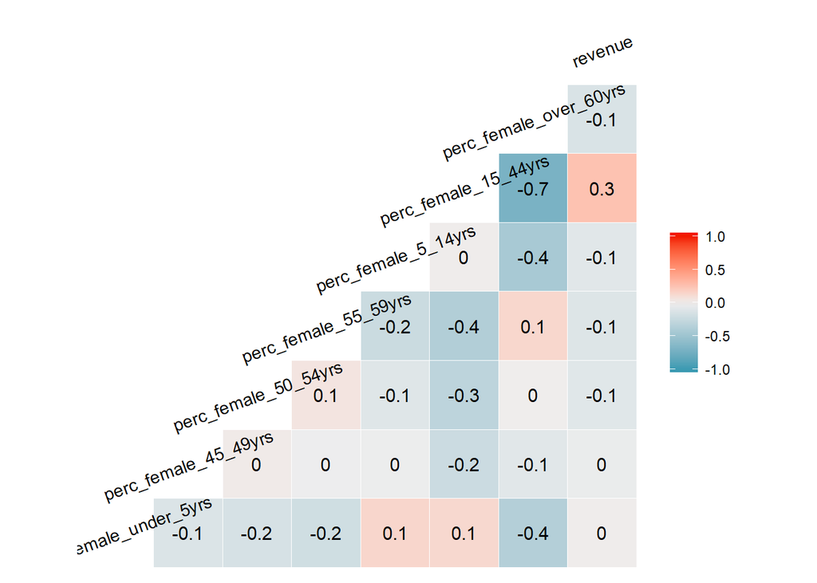

```r
ggcorr(df3, label = TRUE, angle = 20)
```

**Popularity Bivariate Analysis-I**

Variables which have separation in distribution of Popular Products:

- tot_population
- tot_male_population
- tot_female_population
- male_median_age
- female_median_age

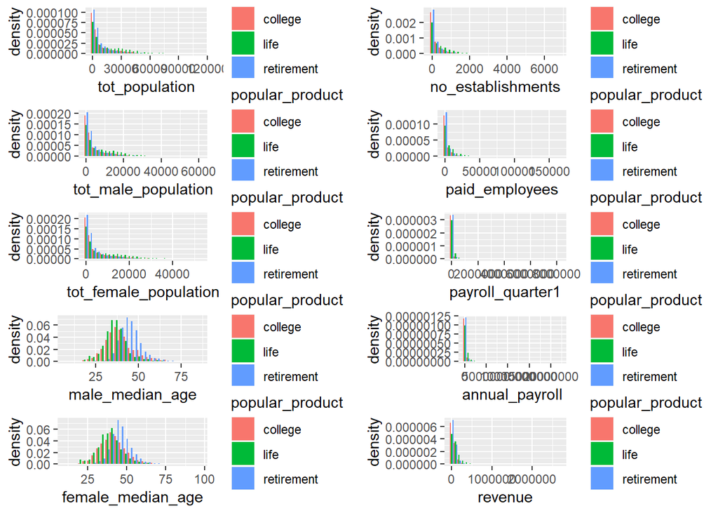

```r
distribution_plot <- function(x, name)
{
  ggplot(data, aes(x=x, fill=popular_product)) +
    geom_histogram(position = 'dodge', aes(y=..density..)) +
    labs(x=name)
}

p1 <- distribution_plot(data$tot_population,"tot_population")
p2 <- distribution_plot(data$tot_male_population,"tot_male_population")
p3 <- distribution_plot(data$tot_female_population,"tot_female_population")
p4 <- distribution_plot(data$male_median_age,"male_median_age")
p5 <- distribution_plot(data$female_median_age,"female_median_age")
p6 <- distribution_plot(data$no_establishments,"no_establishments")
p7 <- distribution_plot(data$paid_employees,"paid_employees")
p8 <- distribution_plot(data$payroll_quarter1,"payroll_quarter1")
p9 <- distribution_plot(data$annual_payroll,"annual_payroll")
p10 <- distribution_plot(data$revenue,"revenue")

Rmisc::multiplot(p1, p2, p3, p4, p5, p6, p7, p8, p9, p10, cols = 2)
```

**Popularity Bivariate Analysis-II**

Variables which have separation in distribution of Popular Products:

- perc_male_under_5yrs
- perc_male_15_44yrs
- perc_male_45_49yrs

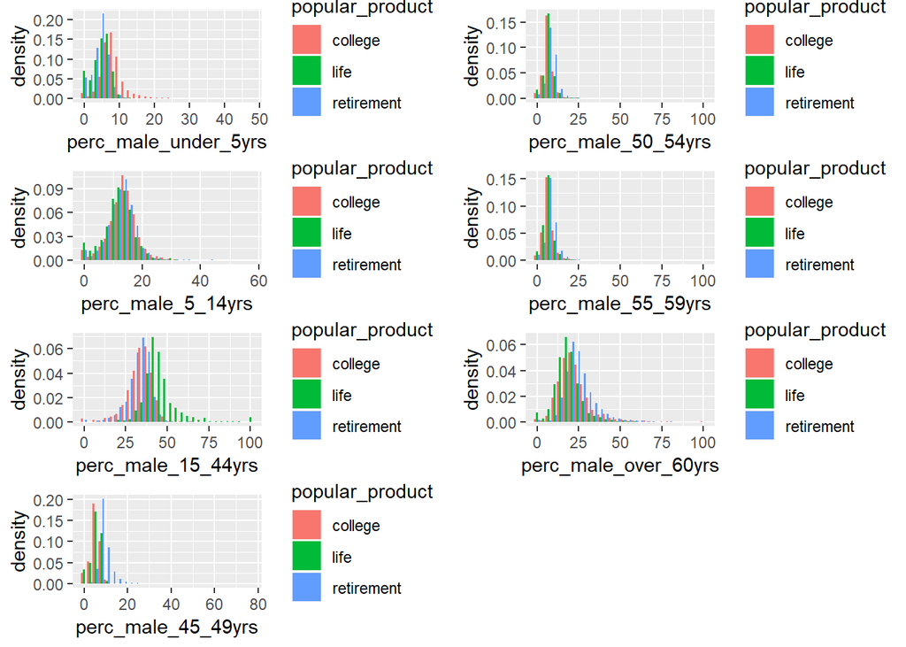

```r
p1 <- distribution_plot(data$perc_male_under_5yrs,"perc_male_under_5yrs")
p2 <- distribution_plot(data$perc_male_5_14yrs,"perc_male_5_14yrs")
p3 <- distribution_plot(data$perc_male_15_44yrs,"perc_male_15_44yrs")
p4 <- distribution_plot(data$perc_male_45_49yrs,"perc_male_45_49yrs")
p5 <- distribution_plot(data$perc_male_50_54yrs,"perc_male_50_54yrs")
p6 <- distribution_plot(data$perc_male_55_59yrs,"perc_male_55_59yrs")
p7 <- distribution_plot(data$perc_male_over_60yrs,"perc_male_over_60yrs")

Rmisc::multiplot(p1, p2, p3, p4, p5, p6, p7, cols = 2)
```

**Popularity Bivariate Analysis-III**

Variables which have separation in distribution of Popular Products:

- perc_female_15_44yrs
- perc_female_45_49yrs

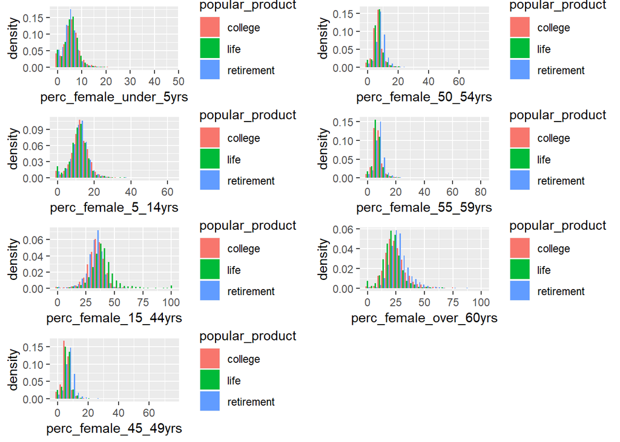

```r
p1 <- distribution_plot(data$perc_female_under_5yrs,"perc_female_under_5yrs")
p2 <- distribution_plot(data$perc_female_5_14yrs,"perc_female_5_14yrs")
p3 <- distribution_plot(data$perc_female_15_44yrs,"perc_female_15_44yrs")
p4 <- distribution_plot(data$perc_female_45_49yrs,"perc_female_45_49yrs")
p5 <- distribution_plot(data$perc_female_50_54yrs,"perc_female_50_54yrs")
p6 <- distribution_plot(data$perc_female_55_59yrs,"perc_female_55_59yrs")
p7 <- distribution_plot(data$perc_female_over_60yrs,"perc_female_over_60yrs")

Rmisc::multiplot(p1, p2, p3, p4, p5, p6, p7, cols = 2)
```

## Model

### Model Building

**Dividing data into train and test set**

```r
# 80-20 train vs test split
set.seed(1)
index<-sample(nrow(data),nrow(data)*0.8)
train<-data[index,]
test<-data[-index,]
```

**Building the model to predict Revenue**

- The following model has been built using Linear Regression
- The variable selection has been done using forward selection (BIC)

```r
# Null Model - Regress square feet on only the intercept
nullmodel=lm(revenue~1, data=train)

# Full Model - Regress square feet on all predictor variables
fullmodel=lm(revenue ~  .-Id2-geographic_area_name-popular_product
             , data=train)

# Final Model built using stepwise variable selection (BIC)
model_revenue <- step(nullmodel, scope=list(lower=nullmodel, upper=fullmodel),
                         direction = c("forward"), k=log(nrow(train)))
```

**Model Summary**

The adjusted R square of the model is ~99%

```r
summary(model_revenue)
```

```
##
## Call:
## lm(formula = revenue ~ paid_employees + payroll_quarter1 + no_establishments +
##     annual_payroll + tot_male_population + perc_male_5_14yrs +
##     perc_female_15_44yrs + perc_female_over_60yrs + perc_male_15_44yrs +
##     perc_male_over_60yrs, data = train)
##
## Residuals:
##     Min      1Q  Median      3Q     Max
## -106003   -3512     160    3656  129563
##
## Coefficients:
##                            Estimate   Std. Error t value
## (Intercept)            21666.572597  1139.057724  19.021
## paid_employees             0.537635     0.049095  10.951
## payroll_quarter1           0.039493     0.003333  11.849
## no_establishments        105.430307     0.669318 157.519
## annual_payroll             0.068797     0.001306  52.694
## tot_male_population       -0.249488     0.022758 -10.963
## perc_male_5_14yrs        -52.203677    22.976294  -2.272
## perc_female_15_44yrs      81.041546    15.869788   5.107
## perc_female_over_60yrs    66.357749    16.549801   4.010
## perc_male_15_44yrs        84.371563    16.939855   4.981
## perc_male_over_60yrs      69.693437    19.040925   3.660
##                                    Pr(>|t|)
## (Intercept)            < 0.0000000000000002 ***
## paid_employees         < 0.0000000000000002 ***
## payroll_quarter1       < 0.0000000000000002 ***
## no_establishments      < 0.0000000000000002 ***
## annual_payroll         < 0.0000000000000002 ***
## tot_male_population    < 0.0000000000000002 ***
## perc_male_5_14yrs                  0.023122 *
## perc_female_15_44yrs            0.000000339 ***
## perc_female_over_60yrs          0.000061655 ***
## perc_male_15_44yrs              0.000000654 ***
## perc_male_over_60yrs               0.000254 ***
## ---
## Signif. codes:  0 '***' 0.001 '**' 0.01 '*' 0.05 '.' 0.1 ' ' 1
##
## Residual standard error: 6940 on 5353 degrees of freedom
## Multiple R-squared:  0.9946, Adjusted R-squared:  0.9946
## F-statistic: 9.808e+04 on 10 and 5353 DF,  p-value: < 0.00000000000000022
```

**Calculating Mean Square Error on Train and Test Set**

Train and Test MSEs are comparable, thus there seems to be no overfitting

```r
# prediction on train set
linear_regression_pred_train <- predict(model_revenue)

# prediction on test set
linear_regression_pred_test <- predict(model_revenue,
                                      newdata=test)

# train MSE
linear_regression_train_mse <- mean((linear_regression_pred_train-train$revenue)^2)

# test MSE
linear_regression_test_mse <- mean((linear_regression_pred_test-test$revenue)^2)

cat("Train MSE:", linear_regression_train_mse, "| Test MSE:", linear_regression_test_mse)
```

```
## Train MSE: 48065318 | Test MSE: 45795763
```

**Building the model to predict the popularity of product**

```r
# Multinomial Logistics Regression
model_pop_product <- multinom(popular_product ~
                              male_median_age
                              +female_median_age
                              +tot_population
                              +tot_male_population
                              +tot_female_population
                              +perc_male_under_5yrs
                              +perc_male_15_44yrs
                              +perc_male_45_49yrs
                              +perc_male_over_60yrs
                              +perc_female_under_5yrs
                              +perc_female_15_44yrs
                              +perc_female_45_49yrs
                              +perc_female_over_60yrs
                              , select(train, -geographic_area_name, -Id2, -revenue), maxit=200)

# performing forward selection (AIC)
model_pop_product_step <- step(model_pop_product)
```

**Model Summary**

```r
summary(model_pop_product_step)
```

```
## Call:
## multinom(formula = popular_product ~ male_median_age + tot_population +
##     tot_male_population + tot_female_population + perc_male_under_5yrs +
##     perc_male_15_44yrs + perc_male_45_49yrs + perc_female_15_44yrs +
##     perc_female_45_49yrs + perc_female_over_60yrs, data = select(train,
##     -geographic_area_name, -Id2, -revenue), maxit = 200)
##
## Coefficients:
##            (Intercept) male_median_age tot_population tot_male_population
## life         -63.96765      -0.1192173 0.000007577717       -0.0002616518
## retirement   -10.82925      -0.1518854 0.000009655579       -0.0003251257
##            tot_female_population perc_male_under_5yrs perc_male_15_44yrs
## life                0.0002682052            -9.712368         3.24700966
## retirement          0.0003353229            -9.637377         0.05265874
##            perc_male_45_49yrs perc_female_15_44yrs perc_female_45_49yrs
## life               -0.0580214           0.08844885           0.04047339
## retirement         10.0168383           0.07618278          -0.11984784
##            perc_female_over_60yrs
## life                   0.08778008
## retirement             0.07599648
##
## Std. Errors:
##              (Intercept) male_median_age tot_population
## life       0.00007243927      0.01532116 0.000007927697
## retirement 0.00004870983      0.01328432 0.000009170222
##            tot_male_population tot_female_population perc_male_under_5yrs
## life              0.0002276797          0.0002232655          0.004143988
## retirement        0.0002778930          0.0002720334          0.004521807
##            perc_male_15_44yrs perc_male_45_49yrs perc_female_15_44yrs
## life               0.01308191        0.005274154           0.01542477
## retirement         0.01605085        0.002400195           0.01779370
##            perc_female_45_49yrs perc_female_over_60yrs
## life                0.008113711             0.01753665
## retirement          0.004736040             0.01402347
##
## Residual Deviance: 599.6059
## AIC: 639.6059
```

**Confusion matrix on train set**

Accuracy Rate: 98.84%

```r
conf_matrix_train <-
  table(train$popular_product,predict(model_pop_product))

conf_matrix_train
```

```
##
##              college life retirement
##   college       1777   11         14
##   life             7 1660          7
##   retirement      19    4       1865
```

**Confusion matrix on test set**

Accuracy Rate: 97.83%

```r
conf_matrix_test <-
  table(test$popular_product,predict(model_pop_product, newdata = test))

conf_matrix_test
```

```
##
##              college life retirement
##   college        415    1          9
##   life             3  424          0
##   retirement      11    5        474
```

### Model Diagonostics

1. **Errors are normally distributed with mean=0**

Using a Q-Q Plot, errors seem to be normally distributed. However, both the tails seem to be heavily skewed due to outliers.

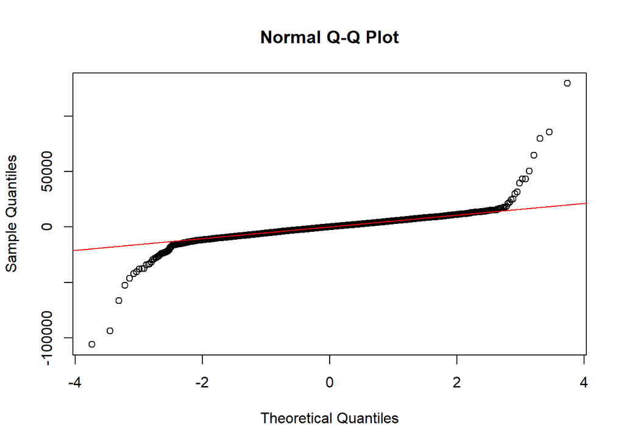

```r
# Constructing a dataframe containing model attributes
model_attributes1 <-
  data.frame(index=1:nrow(train),
             residuals = model_revenue$residuals,
             fitted_values = model_revenue$fitted.values)

# Constructing Q-Q Plot
qqnorm(model_attributes1$residuals)
qqline(model_attributes1$residuals, col='red')
```

2. **Uncorrelated Errors**

There seems to be **no pattern** for the errors over time (index). Thus we can safely assume that the errors are uncorrelated.

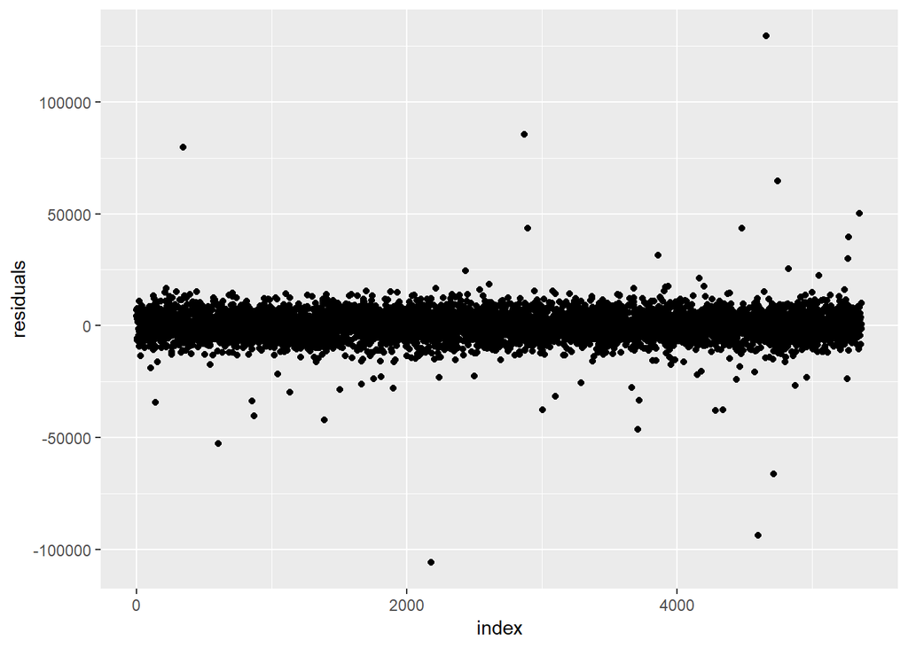

```r
# Plotting Residuals over Time
model_attributes1 %>%
  ggplot(aes(x=index,y=residuals)) +
  geom_point()
```

3. **Constance Variance**

We can clearly see that the residuals are **constantly varied** across the majority of the fitted values. However, for very large fitted values, the variation seems to fan out. If we remove the outliers, we would remove the fan shaped variance as well.

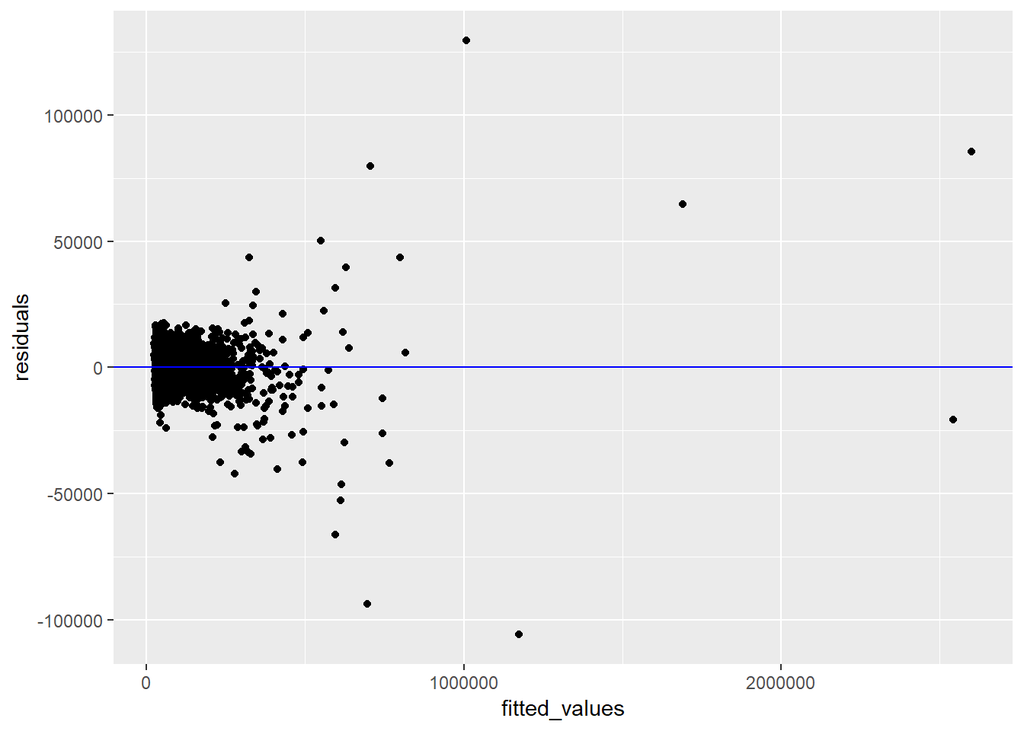

```r
# Residuals vs Fitted-Value Plot
ggplot(model_attributes1, aes(x=fitted_values,y=residuals)) +
  geom_point() +
  geom_hline(yintercept = 0, color = "red") +
  geom_hline(yintercept = 3, color = "blue") +
  geom_hline(yintercept = -3, color = "blue")
```

4. **Predictor Variables are independent of each other**

**Variation Inflation Factor** is high for a few variables like *annual_payroll*, *payroll_quarter1* and *paid_employees*. We will need to remove some of these to reduce multi-collinearity

```r
vif(model_revenue)
```

```
##         paid_employees       payroll_quarter1      no_establishments
##              17.593212              52.967413               8.692075
##         annual_payroll    tot_male_population      perc_male_5_14yrs
##              84.343784               3.042816               1.653595
##   perc_female_15_44yrs perc_female_over_60yrs     perc_male_15_44yrs
##               2.944912               3.355291               3.635962
##   perc_male_over_60yrs
##               4.494583
```

5. **No influential outliers**

Almost all **standardized errors** are below the absolute value of 5. However, there are a few observation that are over the absolute value of 5 and hence can be considered as influential outliers. In an ideal case, these should be removed.

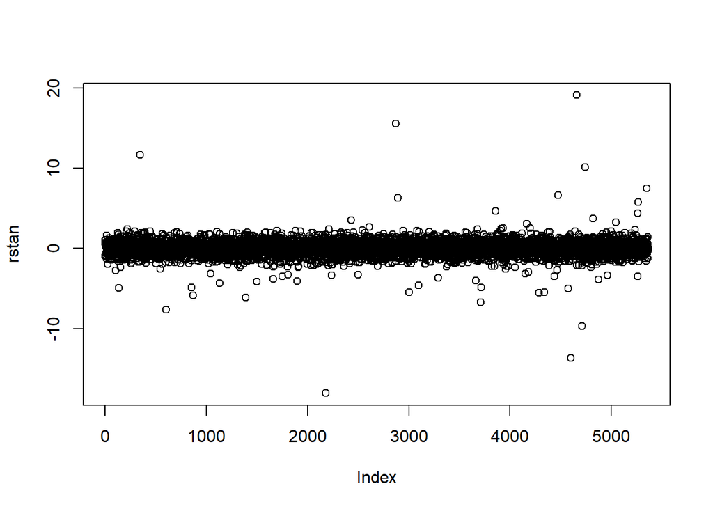

```r
# Plotting Studentized/Standardized Errors
rstan <- rstandard(model_revenue)
plot(rstan)
```

### Corrected Model

**Removing Influential Outliers**

```r
# calculating cooks distance
cooksd <- cooks.distance(model_revenue)

# influential outliers row numbers
influential <- as.numeric(names(cooksd)[(cooksd > mean(cooksd, na.rm=T))])

# remove influential outliers
train <- train[-influential,]
```

**Building the model to predict Revenue**

- The following model has been built using Linear Regression
- The variable selection has been done using forward selection (BIC)
- *annual_payroll* and *paid_employees* is removed to reduce multi-collinearity

```r
# Null Model - Regress square feet on only the intercept
nullmodel=lm(revenue~1, data=train)

# Full Model - Regress square feet on all predictor variables except annual_payroll
fullmodel=lm(revenue ~  .-Id2-geographic_area_name-popular_product-annual_payroll-paid_employees
             , data=train)

# Final Model built using stepwise variable selection (BIC)
model_revenue <- step(nullmodel, scope=list(lower=nullmodel, upper=fullmodel),
                         direction = c("forward"), k=log(nrow(train)))
```

**Model Summary**

The adjusted R square of the model is ~99%

```r
summary(model_revenue)
```

```
##
## Call:
## lm(formula = revenue ~ no_establishments + payroll_quarter1 +
##     perc_male_5_14yrs + tot_population + perc_male_15_44yrs +
##     perc_female_over_60yrs + perc_female_15_44yrs, data = train)
##
## Residuals:
##    Min     1Q Median     3Q    Max
## -56485  -3607    107   3626  34374
##
## Coefficients:
##                            Estimate   Std. Error t value
## (Intercept)            24568.791530   835.112612  29.420
## no_establishments        113.863276     0.540313 210.736
## payroll_quarter1           0.306316     0.001617 189.485
## perc_male_5_14yrs        -59.928591    18.092538  -3.312
## tot_population            -0.060523     0.010521  -5.753
## perc_male_15_44yrs        58.524142    12.570366   4.656
## perc_female_over_60yrs    87.225537    12.370295   7.051
## perc_female_15_44yrs      54.477925    14.006055   3.890
##                                    Pr(>|t|)
## (Intercept)            < 0.0000000000000002 ***
## no_establishments      < 0.0000000000000002 ***
## payroll_quarter1       < 0.0000000000000002 ***
## perc_male_5_14yrs                  0.000931 ***
## tot_population               0.000000009279 ***
## perc_male_15_44yrs           0.000003307055 ***
## perc_female_over_60yrs       0.000000000002 ***
## perc_female_15_44yrs               0.000102 ***
## ---
## Signif. codes:  0 '***' 0.001 '**' 0.01 '*' 0.05 '.' 0.1 ' ' 1
##
## Residual standard error: 6067 on 5312 degrees of freedom
## Multiple R-squared:  0.9913, Adjusted R-squared:  0.9912
## F-statistic: 8.605e+04 on 7 and 5312 DF,  p-value: < 0.00000000000000022
```

**Calculating Mean Square Error on Train and Test Set**

```r
# prediction on train set
linear_regression_pred_train <- predict(model_revenue)

# prediction on test set
linear_regression_pred_test <- predict(model_revenue,
                                      newdata=test)

# train MSE
linear_regression_train_mse <- mean((linear_regression_pred_train-train$revenue)^2)

# test MSE
linear_regression_test_mse <- mean((linear_regression_pred_test-test$revenue)^2)

cat("Train MSE:", linear_regression_train_mse, "| Test MSE:", linear_regression_test_mse)
```

```
## Train MSE: 36752185 | Test MSE: 321499258
```

**Building the model to predict the popularity of product**

```r
# Multinomial Logistics Regression
model_pop_product <- multinom(popular_product ~
                              male_median_age
                              +female_median_age
                              +tot_population
                              +tot_male_population
                              +tot_female_population
                              +perc_male_under_5yrs
                              +perc_male_15_44yrs
                              +perc_male_45_49yrs
                              +perc_male_over_60yrs
                              +perc_female_under_5yrs
                              +perc_female_15_44yrs
                              +perc_female_45_49yrs
                              +perc_female_over_60yrs
                              , select(train, -geographic_area_name, -Id2, -revenue), maxit=200)

# performing forward selection (AIC)
model_pop_product_step <- step(model_pop_product)
```

**Model Summary**

```r
summary(model_pop_product_step)
```

```
## Call:
## multinom(formula = popular_product ~ male_median_age + tot_population +
##     tot_male_population + tot_female_population + perc_male_under_5yrs +
##     perc_male_15_44yrs + perc_male_45_49yrs + perc_female_15_44yrs +
##     perc_female_45_49yrs + perc_female_over_60yrs, data = select(train,
##     -geographic_area_name, -Id2, -revenue), maxit = 200)
##
## Coefficients:
##            (Intercept) male_median_age tot_population tot_male_population
## life         -63.97387      -0.1186000 0.000007263478       -0.0002651740
## retirement   -10.77528      -0.1520542 0.000010230867       -0.0003063879
##            tot_female_population perc_male_under_5yrs perc_male_15_44yrs
## life                0.0002721347            -9.720721          3.2471242
## retirement          0.0003166178            -9.650487          0.0560999
##            perc_male_45_49yrs perc_female_15_44yrs perc_female_45_49yrs
## life              -0.05536281           0.09030834           0.03580886
## retirement         9.99796531           0.07939600          -0.13179365
##            perc_female_over_60yrs
## life                    0.0871428
## retirement              0.0761664
##
## Std. Errors:
##              (Intercept) male_median_age tot_population
## life       0.00007348353      0.01536158 0.000007966623
## retirement 0.00004912882      0.01327730 0.000009400856
##            tot_male_population tot_female_population perc_male_under_5yrs
## life              0.0002295425          0.0002250732          0.004113861
## retirement        0.0002871352          0.0002809541          0.004432349
##            perc_male_15_44yrs perc_male_45_49yrs perc_female_15_44yrs
## life               0.01312008        0.005267846           0.01544974
## retirement         0.01604569        0.002397547           0.01782996
##            perc_female_45_49yrs perc_female_over_60yrs
## life                0.008229996             0.01756903
## retirement          0.004837625             0.01399654
##
## Residual Deviance: 596.7282
## AIC: 636.7282
```

**Confusion matrix on train set**

```r
conf_matrix_train <-
  table(train$popular_product,predict(model_pop_product))

conf_matrix_train
```

```
##
##              college life retirement
##   college       1772   11         12
##   life             7 1634          7
##   retirement      18    5       1854
```

**Confusion matrix on test set**

```r
conf_matrix_test <-
  table(test$popular_product,predict(model_pop_product, newdata = test))

conf_matrix_test
```

```
##
##              college life retirement
##   college        414    2          9
##   life             3  424          0
##   retirement      11    5        474
```

### Corrected Model Diagonostics

1. **Errors are normally distributed with mean=0**

Using a Q-Q Plot, errors seem to be normally distributed.

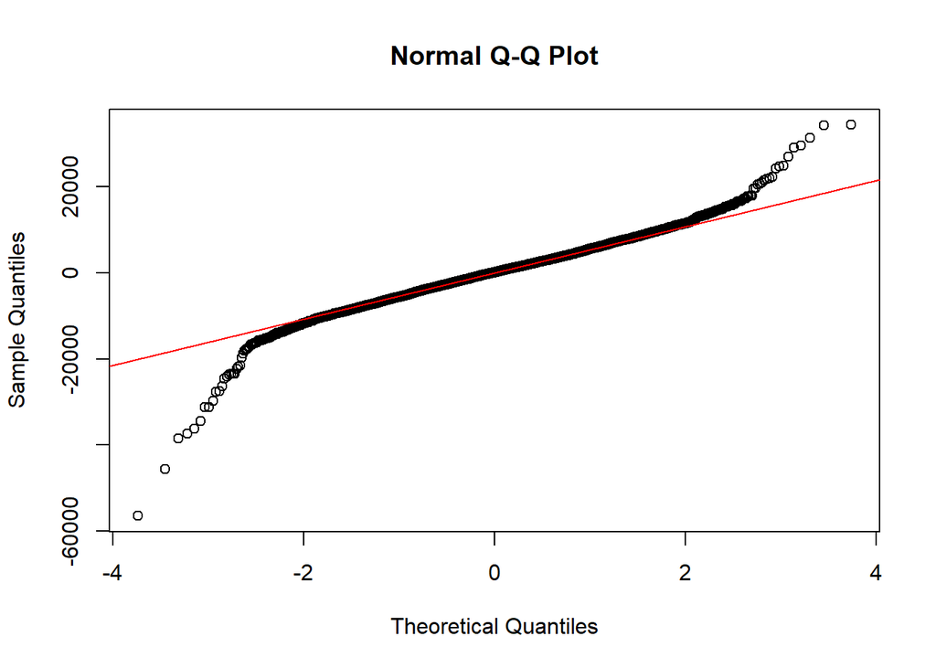

```r
# Constructing a dataframe containing model attributes
model_attributes1 <-
  data.frame(index=1:nrow(train),
             residuals = model_revenue$residuals,
             fitted_values = model_revenue$fitted.values)

# Constructing Q-Q Plot
qqnorm(model_attributes1$residuals)
qqline(model_attributes1$residuals, col='red')
```

2. **Uncorrelated Errors**

There seems to be **no pattern** for the errors over time (index). Thus we can safely assume that the errors are uncorrelated.

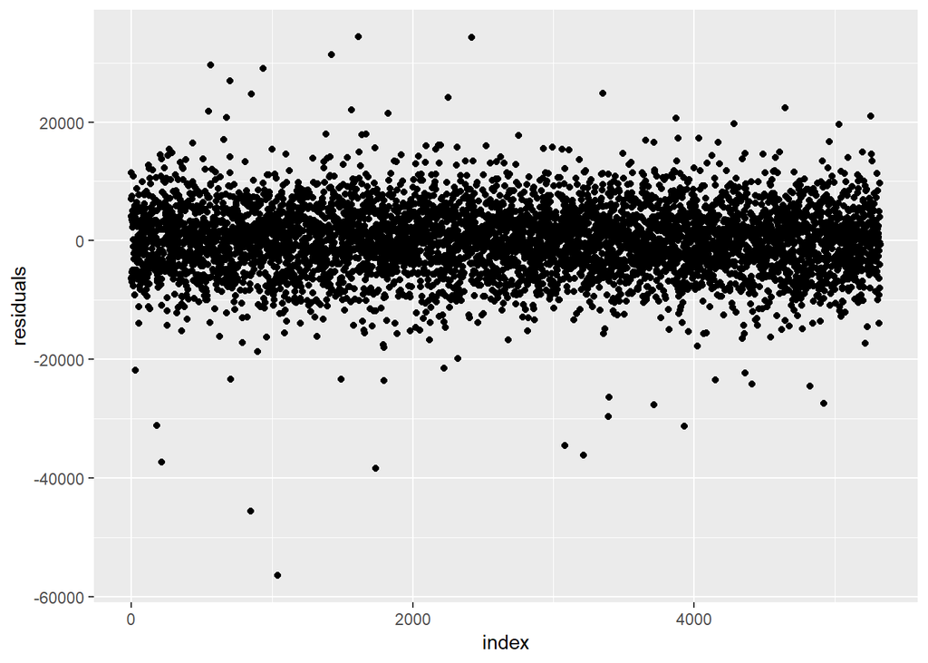

```r
# Plotting Residuals over Time
model_attributes1 %>%
  ggplot(aes(x=index,y=residuals)) +
  geom_point()
```

3. **Constance Variance**

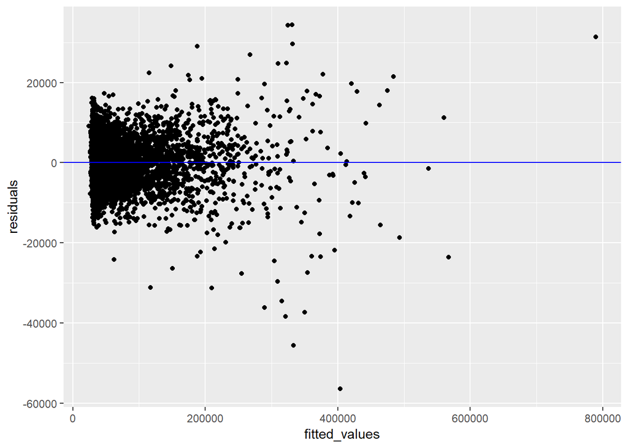

```r
# Residuals vs Fitted-Value Plot
ggplot(model_attributes1, aes(x=fitted_values,y=residuals)) +
  geom_point() +
  geom_hline(yintercept = 0, color = "red") +
  geom_hline(yintercept = 3, color = "blue") +
  geom_hline(yintercept = -3, color = "blue")
```

4. **Predictor Variables are independent of each other**

**Variation Inflation Factor** <10 for all variables. Thus their is no multi-collinearity.

```r
vif(model_revenue)
```

```
##      no_establishments       payroll_quarter1      perc_male_5_14yrs
##               5.844737               2.785597               1.318786
##         tot_population     perc_male_15_44yrs perc_female_over_60yrs
##               3.459487               2.494747               2.396186
##   perc_female_15_44yrs
##               2.850943
```

5. **No influential outliers**

Almost all **standardized errors** are below the absolute value of 5.

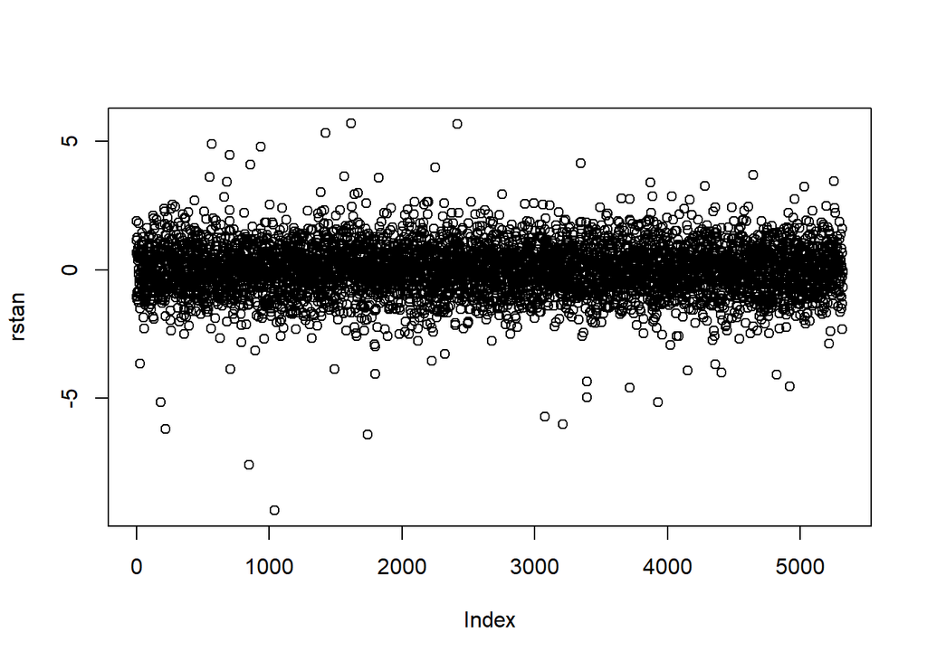

```r
# Plotting Studentized/Standardized Errors
rstan <- rstandard(model_revenue)
plot(rstan)
```

### Model Interpretation

**Linear Regression - Predicting Revenue**

- Revenue = output variable
- **99% variance** in the output variable is explained by:
  - no_establishments
  - payroll_quarter1
  - perc_male_5_14yrs
  - tot_population
  - perc_male_15_44yrs
  - perc_female_over_60yrs
  - perc_female_15_44yrs
- All held constant, with 1 unit increase in no_establishments, the average revenue **increases by $113.86**.
- A more concrete way of elaborating the above point would be: All held constant, we are **95 % confident** that with 1 unit increase in no_establishments, the average revenue **increases by $112.78 - $114.94**.
- All other predictor variables can be interpretted in the same way.
- The **t-tests** correspond to the following hypothesis test:
  - H0: Beta = 0
  - HA: Beta !=0
  - For all p-values < 0.05, we reject H0
  - All predictor variables have p-value < 0.05
- The **f-test** correspond to the following hypothesis test:
  - H0: All Beta’s = 0
  - HA: At least one Beta != 0
  - As p-value < 0.05, we reject H0. **Thus our model as a whole is significant**.

## Insights

### Future Work

1. Perform cross-validation to find the optimal **k** in k-nearest neighbour algorithm.
2. Perform cross-validation on both the **regression and classfication models** to verify that the models are not overfitting.
3. Perform **transformation on response and/or predictor variables** to satisfy the assumptions of the linear regression model (better than current model).
4. Use **different variable selection techniques** like backward, stepwise and lasso on parameters like adjusted R square, AIC, BIC, deviance, p-value etc.
5. Use more **advanced models** like decision trees, random forest, bagging and boosting to increase accuracy.